# Personal Movement Analysis

Manuel A. Cerda R.

3 de abril de 2016

# Abstract

It is now possible to collect a large amount of data about personal movement using activity monitoring devices such as a [Fitbit](http://www.fitbit.com/), [Nike Fuelband](http://www.nike.com/us/en_us/c/nikeplus-fuel), or [Jawbone Up](https://jawbone.com/up). These type of devices are part of the “quantified self” movement - a group of enthusiasts who take measurements about themselves regularly to improve their health, to find patterns in their behavior, or because they are tech geeks. But these data remain under-utilized both because the raw data are hard to obtain and there is a lack of statistical methods and software for processing and interpreting the data.

This assignment makes use of data from a personal activity monitoring device. This device collects data at 5 minute intervals through out the day. The data consists of two months of data from an anonymous individual collected during the months of October and November, 2012 and include the number of steps taken in 5 minute intervals each day.

### Content

1. Data Processing
2. Data Analysis
3. Data Analysis after Imputing Missing Values
4. Comparative Analysis

### Data Processing

The data for this assignment can be downloaded from the course web site:

- Dataset: [Activity monitoring data](https://d396qusza40orc.cloudfront.net/repdata%2Fdata%2Factivity.zip) [52K]

```r
temp <- tempfile()
if (exists("setInternet2", mode = "function")) setInternet2(use = TRUE)
download.file("https://d396qusza40orc.cloudfront.net/repdata%2Fdata%2Factivity.zip",
    temp)
measuredData <- read.csv(unz(temp, "activity.csv"))
unlink(temp)
```

The variables included in this dataset are (**steps, date, interval**):

```
##   steps       date interval
## 1    NA 2012-10-01        0
```

- **steps:** Number of steps taking in a 5-minute interval (missing values are coded as NA)
- **date:** The date on which the measurement was taken in YYYY-MM-DD format
- **interval:** Identifier for the 5-minute interval in which measurement was taken

```r
obsCount <- nrow(measuredData)
naStepCount <- length(measuredData$steps[is.na(measuredData$steps)])
```

The dataset is stored in a comma-separated-value (CSV) file and there are a total of **17,568** observations with **2,304** NA steps in this dataset.

**steps** with missing values are ignored.

### Data Analysis

```r
analyticData <- measuredData[complete.cases(measuredData),]
analyticData$steps <- as.numeric(analyticData$steps)
analyticData$date <- as.Date(analyticData$date, "%Y-%m-%d")
```

A total of **15,264** observations are curated for analysis.

```
##     steps       date interval
## 289     0 2012-10-02        0
## 290     0 2012-10-02        5
```

```
##       steps       date interval
## 17279     0 2012-11-29     2350
## 17280     0 2012-11-29     2355
```

**Mean Total number of Steps per Day**

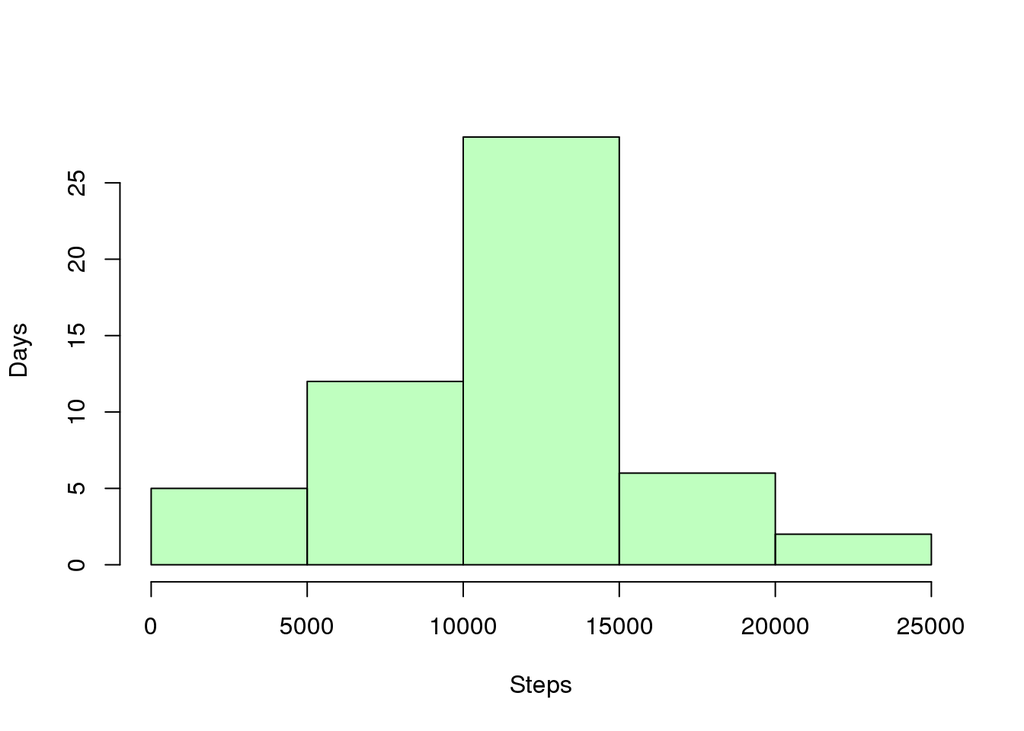

```r
sumData <- ddply(analyticData, "date", summarise, steps = sum(steps))

hist(sumData$steps, freq= T, ylab= "Days", xlab="Steps", main="", col=rgb(0, 1, 0, 0.25))
```

```r
meanSteps <- mean(sumData$steps)
medianSteps <- median(sumData$steps)
```

Analysis show a Mean of **10,766.19** and a Median of **10,765** steps per day from **02 Oct 2012** to **29 Nov 2012**.

**Average daily Activity Pattern**

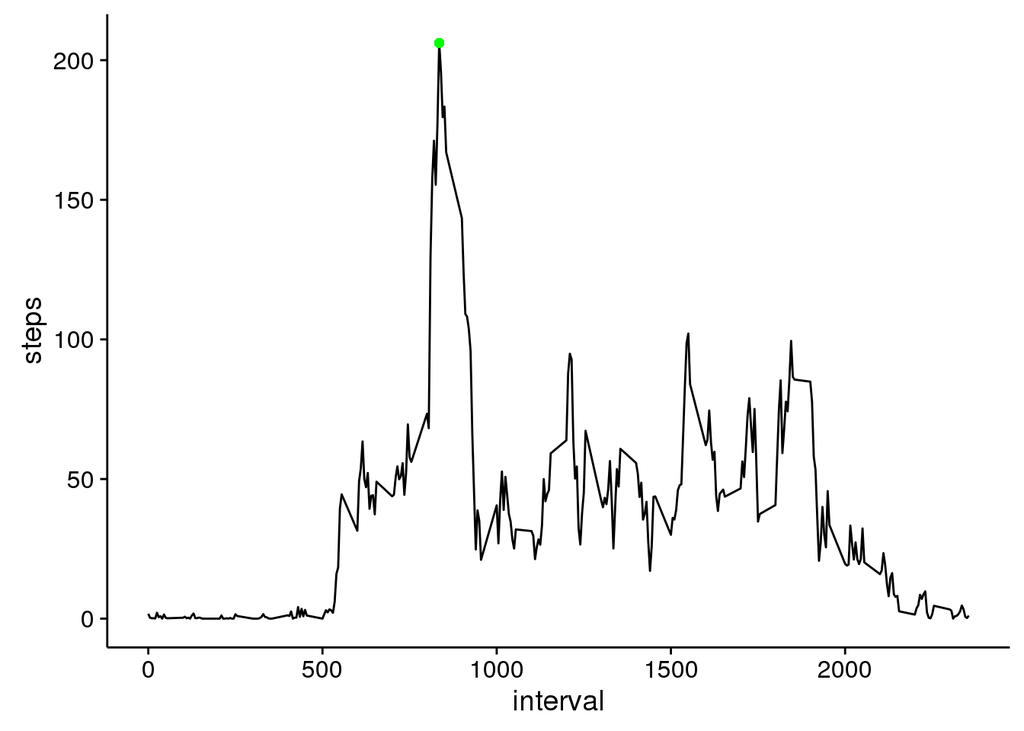

```r
sData <- ddply(analyticData, "interval", summarise, steps = mean(steps))
maxMeanSteps <- max(sData$steps)
maxMeanStepsInterval <- sData$interval[sData$steps == maxMeanSteps]

qplot(interval, steps, data=sData, geom="line") +
  geom_point(aes(x = maxMeanStepsInterval, y = maxMeanSteps), colour="Green")
```

Interval **835** contains the maximum number of steps on average across all the days in the dataset.

### Data Analysis after Imputing Missing Values

All missing values will be substituted for the mean number of steps for the respective day.

```r
imputedAD <- measuredData
iData <- ddply(measuredData, "date", summarise, steps = mean(steps, na.rm = T))
imputedAD$steps <- as.numeric(imputedAD$steps)
iData$date <- as.character(iData$date)
for(index in 1:length(imputedAD$steps))
{
  if(is.na(imputedAD$steps[index]))
  {
    imeanStepsPerDay <- iData$steps[iData$date == imputedAD$date[index]]
    if(is.na(imeanStepsPerDay) == F)
    {
      imputedAD$steps[index] <- imeanStepsPerDay
    }
    else
    {
      imputedAD$steps[index] <- as.numeric(0)
    }
  }
}
imputedAD <- imputedAD[complete.cases(imputedAD),]
imputedAD$date <- as.Date(imputedAD$date, "%Y-%m-%d")
```

```
##   steps       date interval
## 1     0 2012-10-01        0
## 2     0 2012-10-01        5
```

```
##       steps       date interval
## 17567     0 2012-11-30     2350
## 17568     0 2012-11-30     2355
```

**Mean Total number of Steps per Day**

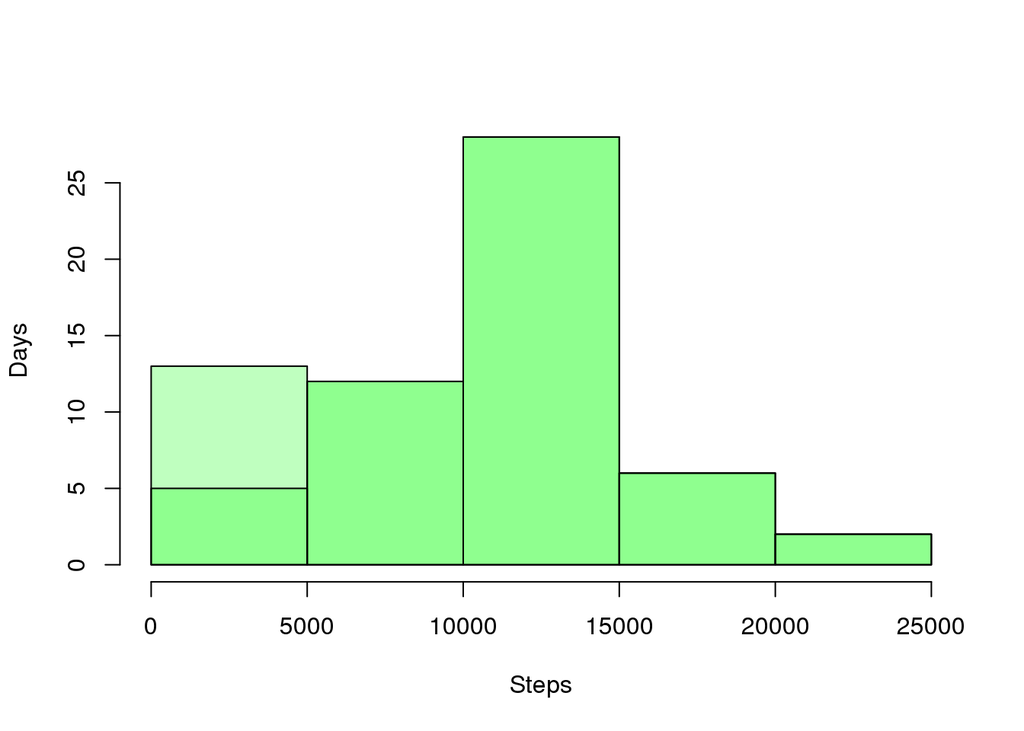

```r
isumData <- ddply(imputedAD, "date", summarise, steps = sum(steps))

imeanSteps <- mean(isumData$steps)
imedianSteps <- median(isumData$steps)

hist(isumData$steps, freq= T, ylab= "Days", xlab="Steps", main="", col=rgb(0, 1, 0, 0.25))
hist(sumData$steps, freq= T, ylab= "Days", xlab="Steps", main="", add=T, col=rgb(0, 1, 0, 0.25))
```

Analysis show a Mean of **9,354.23** and a Median of **10,395** steps per day from **01 Oct 2012** to **30 Nov 2012** after imputing missing values.

**Average daily Activity Pattern**

Now compairing the number of steps per day between weekdays and weekends.

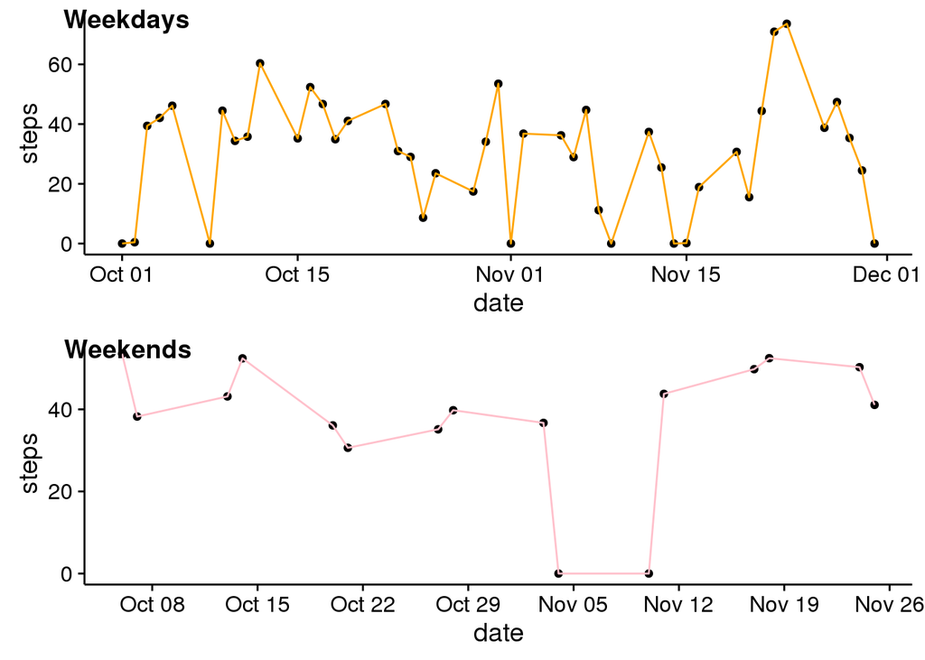

```r
daysData <- ddply(imputedAD, "date", summarise, steps= mean(steps))
daysData$day <- wday(as.Date(daysData$date))

weekdayActivity <- subset(daysData, daysData$day %in% c(2,3,4,5,6))
weekendActivity <- subset(daysData, daysData$day %in% c(1,7))

p1 <- qplot(date, steps, data=weekdayActivity, geom="point") + geom_line(colour="orange")
p2 <- qplot(date, steps, data=weekendActivity, geom="point") + geom_line(colour="pink")

plot_grid(p1, p2, labels=c("Weekdays", "Weekends"), ncol = 1, nrow = 2)
```

### Comparative Analysis

Analysis show a Mean of **10,766.19** and a Median of **10,765** steps per day. And, a Mean of **9,354.23** and a Median of **10,395** steps per day from **01 Oct 2012** to **30 Nov 2012** after imputing missing values.